# IMDB Movie Analysis

```python
#Importing required packages
import numpy as np
import pandas as pd
import seaborn as sns
import matplotlib.pyplot as plt
import plotly.express as px
```

```python
#Importing csv to the dataframe df
df = pd.read_csv('Downloads/IMDB_Movies.csv')
```

```python
#Checking the dataset
df
```

|  | color | director_name | num_critic_for_reviews | duration | director_facebook_likes | actor_3_facebook_likes | actor_2_name | actor_1_facebook_likes | gross | genres | ... | num_user_for_reviews | language | country | content_rating | budget | title_year | actor_2_facebook_likes | imdb_score | aspect_ratio | movie_facebook_likes |
| --- | --- | --- | --- | --- | --- | --- | --- | --- | --- | --- | --- | --- | --- | --- | --- | --- | --- | --- | --- | --- | --- |
| 0 | Color | James Cameron | 723.0 | 178.0 | 0.0 | 855.0 | Joel David Moore | 1000.0 | 760505847.0 | Action\|Adventure\|Fantasy\|Sci-Fi | ... | 3054 | English | USA | PG-13 | 237000000.0 | 2009.0 | 936.0 | 7.9 | 1.78 | 33000 |
| 1 | Color | Gore Verbinski | 302.0 | 169.0 | 563.0 | 1000.0 | Orlando Bloom | 40000.0 | 309404152.0 | Action\|Adventure\|Fantasy | ... | 1238 | English | USA | PG-13 | 300000000.0 | 2007.0 | 5000.0 | 7.1 | 2.35 | 0 |
| 2 | Color | Sam Mendes | 602.0 | 148.0 | 0.0 | 161.0 | Rory Kinnear | 11000.0 | 200074175.0 | Action\|Adventure\|Thriller | ... | 994 | English | UK | PG-13 | 245000000.0 | 2015.0 | 393.0 | 6.8 | 2.35 | 85000 |
| 3 | Color | Christopher Nolan | 813.0 | 164.0 | 22000.0 | 23000.0 | Christian Bale | 27000.0 | 448130642.0 | Action\|Thriller | ... | 2701 | English | USA | PG-13 | 250000000.0 | 2012.0 | 23000.0 | 8.5 | 2.35 | 164000 |
| 4 | NaN | Doug Walker | NaN | NaN | 131.0 | NaN | Rob Walker | 131.0 | NaN | Documentary | ... |  | NaN | NaN | NaN | NaN | NaN | 12.0 | 7.1 | NaN | 0 |
| ... | ... | ... | ... | ... | ... | ... | ... | ... | ... | ... | ... | ... | ... | ... | ... | ... | ... | ... | ... | ... | ... |
| 5038 | Color | Scott Smith | 1.0 | 87.0 | 2.0 | 318.0 | Daphne Zuniga | 637.0 | NaN | Comedy\|Drama | ... | 6 | English | Canada | NaN | NaN | 2013.0 | 470.0 | 7.7 | NaN | 84 |
| 5039 | Color | NaN | 43.0 | 43.0 | NaN | 319.0 | Valorie Curry | 841.0 | NaN | Crime\|Drama\|Mystery\|Thriller | ... | 359 | English | USA | TV-14 | NaN | NaN | 593.0 | 7.5 | 16.00 | 32000 |
| 5040 | Color | Benjamin Roberds | 13.0 | 76.0 | 0.0 | 0.0 | Maxwell Moody | 0.0 | NaN | Drama\|Horror\|Thriller | ... | 3 | English | USA | NaN | 1400.0 | 2013.0 | 0.0 | 6.3 | NaN | 16 |
| 5041 | Color | Daniel Hsia | 14.0 | 100.0 | 0.0 | 489.0 | Daniel Henney | 946.0 | 10443.0 | Comedy\|Drama\|Romance | ... | 9 | English | USA | PG-13 | NaN | 2012.0 | 719.0 | 6.3 | 2.35 | 660 |
| 5042 | Color | Jon Gunn | 43.0 | 90.0 | 16.0 | 16.0 | Brian Herzlinger | 86.0 | 85222.0 | Documentary | ... | 84 | English | USA | PG | 1100.0 | 2004.0 | 23.0 | 6.6 | 1.85 | 456 |

5043 rows × 28 columns

**A.Cleaning the data:** This is one of the most important step to perform before moving forward with the analysis. Use your knowledge learned till now to do this. (Dropping columns, removing null values, etc.  
**Hint:** Clean the data

```python
# Checking the columns for analysis
df.columns
```

```
Index(['color', 'director_name', 'num_critic_for_reviews', 'duration',
       'director_facebook_likes', 'actor_3_facebook_likes', 'actor_2_name',
       'actor_1_facebook_likes', 'gross', 'genres', 'actor_1_name',
       'movie_title', 'num_voted_users', 'cast_total_facebook_likes',
       'actor_3_name', 'facenumber_in_poster', 'plot_keywords',
       'movie_imdb_link', 'num_user_for_reviews', 'language', 'country',
       'content_rating', 'budget', 'title_year', 'actor_2_facebook_likes',
       'imdb_score', 'aspect_ratio', 'movie_facebook_likes'],
      dtype='object')
```

```python
# Dropping unnecessary columns
df = df.drop(['color','director_facebook_likes','actor_1_facebook_likes','actor_2_facebook_likes','actor_3_facebook_likes','actor_2_name','cast_total_facebook_likes','actor_3_name','duration','facenumber_in_poster','content_rating','country','movie_imdb_link','aspect_ratio','plot_keywords'],axis=1)
```

```python
#Finding the number on null values in decreasing order
df.isnull().sum().sort_values(ascending=False)
```

```
gross                     884
budget                    492
title_year                108
director_name             104
num_critic_for_reviews     50
num_user_for_reviews       20
language                   12
actor_1_name                7
genres                      0
movie_title                 0
num_voted_users             0
imdb_score                  0
movie_facebook_likes        0
dtype: int64
```

```python
#Since gross and budget have the most null values I have passed the data frame with not
# null constraint as index to retrieve all not null values
df = df[df['gross'].notnull()]
df = df[df['budget'].notnull()]
```

```python
# Checking after dropping null values in gross and budget
df.isnull().sum(axis=0).sort_values(ascending=False)
```

```
actor_1_name              3
language                  3
num_critic_for_reviews    1
director_name             0
gross                     0
genres                    0
movie_title               0
num_voted_users           0
num_user_for_reviews      0
budget                    0
title_year                0
imdb_score                0
movie_facebook_likes      0
dtype: int64
```

```python
#Dropping all dupicate records
df.drop_duplicates()
```

|  | director_name | num_critic_for_reviews | gross | genres | actor_1_name | movie_title | num_voted_users | num_user_for_reviews | language | budget | title_year | imdb_score | movie_facebook_likes |
| --- | --- | --- | --- | --- | --- | --- | --- | --- | --- | --- | --- | --- | --- |
| 0 | James Cameron | 723.0 | 760505847.0 | Action\|Adventure\|Fantasy\|Sci-Fi | CCH Pounder | Avatar | 886204 | 3054 | English | 237000000.0 | 2009.0 | 7.9 | 33000 |
| 1 | Gore Verbinski | 302.0 | 309404152.0 | Action\|Adventure\|Fantasy | Johnny Depp | Pirates of the Caribbean: At World's End | 471220 | 1238 | English | 300000000.0 | 2007.0 | 7.1 | 0 |
| 2 | Sam Mendes | 602.0 | 200074175.0 | Action\|Adventure\|Thriller | Christoph Waltz | Spectre | 275868 | 994 | English | 245000000.0 | 2015.0 | 6.8 | 85000 |
| 3 | Christopher Nolan | 813.0 | 448130642.0 | Action\|Thriller | Tom Hardy | The Dark Knight Rises | 1144337 | 2701 | English | 250000000.0 | 2012.0 | 8.5 | 164000 |
| 5 | Andrew Stanton | 462.0 | 73058679.0 | Action\|Adventure\|Sci-Fi | Daryl Sabara | John Carter | 212204 | 738 | English | 263700000.0 | 2012.0 | 6.6 | 24000 |
| ... | ... | ... | ... | ... | ... | ... | ... | ... | ... | ... | ... | ... | ... |
| 5033 | Shane Carruth | 143.0 | 424760.0 | Drama\|Sci-Fi\|Thriller | Shane Carruth | Primer | 72639 | 371 | English | 7000.0 | 2004.0 | 7.0 | 19000 |
| 5034 | Neill Dela Llana | 35.0 | 70071.0 | Thriller | Ian Gamazon | Cavite | 589 | 35 | English | 7000.0 | 2005.0 | 6.3 | 74 |
| 5035 | Robert Rodriguez | 56.0 | 2040920.0 | Action\|Crime\|Drama\|Romance\|Thriller | Carlos Gallardo | El Mariachi | 52055 | 130 | Spanish | 7000.0 | 1992.0 | 6.9 | 0 |
| 5037 | Edward Burns | 14.0 | 4584.0 | Comedy\|Drama | Kerry Bishé | Newlyweds | 1338 | 14 | English | 9000.0 | 2011.0 | 6.4 | 413 |
| 5042 | Jon Gunn | 43.0 | 85222.0 | Documentary | John August | My Date with Drew | 4285 | 84 | English | 1100.0 | 2004.0 | 6.6 | 456 |

3856 rows × 13 columns

**B.Movies with highest profit:** Create a new column called profit which contains the difference of the two columns: gross and budget. Sort the column using the profit column as reference. Plot profit (y-axis) vs budget (x- axis) and observe the outliers using the appropriate chart type  
**Hint:** Find the movies with the highest profit?

```python
#Creating a new column profit which is difference between gross and budget
df['profit'] = df['gross'] - df['budget']
df.head()
```

|  | director_name | num_critic_for_reviews | gross | genres | actor_1_name | movie_title | num_voted_users | num_user_for_reviews | language | budget | title_year | imdb_score | movie_facebook_likes | profit |
| --- | --- | --- | --- | --- | --- | --- | --- | --- | --- | --- | --- | --- | --- | --- |
| 0 | James Cameron | 723.0 | 760505847.0 | Action\|Adventure\|Fantasy\|Sci-Fi | CCH Pounder | Avatar | 886204 | 3054 | English | 237000000.0 | 2009.0 | 7.9 | 33000 | 523505847.0 |
| 1 | Gore Verbinski | 302.0 | 309404152.0 | Action\|Adventure\|Fantasy | Johnny Depp | Pirates of the Caribbean: At World's End | 471220 | 1238 | English | 300000000.0 | 2007.0 | 7.1 | 0 | 9404152.0 |
| 2 | Sam Mendes | 602.0 | 200074175.0 | Action\|Adventure\|Thriller | Christoph Waltz | Spectre | 275868 | 994 | English | 245000000.0 | 2015.0 | 6.8 | 85000 | -44925825.0 |
| 3 | Christopher Nolan | 813.0 | 448130642.0 | Action\|Thriller | Tom Hardy | The Dark Knight Rises | 1144337 | 2701 | English | 250000000.0 | 2012.0 | 8.5 | 164000 | 198130642.0 |
| 5 | Andrew Stanton | 462.0 | 73058679.0 | Action\|Adventure\|Sci-Fi | Daryl Sabara | John Carter | 212204 | 738 | English | 263700000.0 | 2012.0 | 6.6 | 24000 | -190641321.0 |

```python
#Sorting on basis of profit (Decreasing Order)
df=df.sort_values(by=['profit'],ascending=False)
```

```python
#Plotting Profit Vs Budget of the films having profit greater than 200M
df1 = df[df.profit>200000000]
fig = px.line(df1, x="budget", y="profit", title='Profit vs Budget',markers=True)
fig.show()
```

[interactive chart not shown]

```python
top10 = df[['movie_title','budget','profit']]
top10.head(10)
```

|  | movie_title | budget | profit |
| --- | --- | --- | --- |
| 0 | Avatar | 237000000.0 | 523505847.0 |
| 29 | Jurassic World | 150000000.0 | 502177271.0 |
| 26 | Titanic | 200000000.0 | 458672302.0 |
| 3024 | Star Wars: Episode IV - A New Hope | 11000000.0 | 449935665.0 |
| 3080 | E.T. the Extra-Terrestrial | 10500000.0 | 424449459.0 |
| 794 | The Avengers | 220000000.0 | 403279547.0 |
| 17 | The Avengers | 220000000.0 | 403279547.0 |
| 509 | The Lion King | 45000000.0 | 377783777.0 |
| 240 | Star Wars: Episode I - The Phantom Menace | 115000000.0 | 359544677.0 |
| 66 | The Dark Knight | 185000000.0 | 348316061.0 |

**C.Top 250:** Create a new column IMDb_Top_250 and store the top 250 movies with the highest IMDb Rating (corresponding to the column: imdb_score). Also make sure that for all of these movies, the num_voted_users is greater than 25,000. Also add a Rank column containing the values 1 to 250 indicating the ranks of the corresponding films.

Extract all the movies in the IMDb_Top_250 column which are not in the English language and store them in a new column named Top_Foreign_Lang_Film. You can use your own imagination also!

**Hint:** Find IMDB Top 250

```python
# Creating a dataframe IMDb_Top_250 having voted users greater than 25000
IMDb_Top_250 = df[df['num_voted_users'] > 25000].sort_values(by='imdb_score',ascending=False).head(250)
IMDb_Top_250
```

|  | director_name | num_critic_for_reviews | gross | genres | actor_1_name | movie_title | num_voted_users | num_user_for_reviews | language | budget | title_year | imdb_score | movie_facebook_likes | profit |
| --- | --- | --- | --- | --- | --- | --- | --- | --- | --- | --- | --- | --- | --- | --- |
| 1937 | Frank Darabont | 199.0 | 28341469.0 | Crime\|Drama | Morgan Freeman | The Shawshank Redemption | 1689764 | 4144 | English | 25000000.0 | 1994.0 | 9.3 | 108000 | 3341469.0 |
| 3466 | Francis Ford Coppola | 208.0 | 134821952.0 | Crime\|Drama | Al Pacino | The Godfather | 1155770 | 2238 | English | 6000000.0 | 1972.0 | 9.2 | 43000 | 128821952.0 |
| 66 | Christopher Nolan | 645.0 | 533316061.0 | Action\|Crime\|Drama\|Thriller | Christian Bale | The Dark Knight | 1676169 | 4667 | English | 185000000.0 | 2008.0 | 9.0 | 37000 | 348316061.0 |
| 2837 | Francis Ford Coppola | 149.0 | 57300000.0 | Crime\|Drama | Robert De Niro | The Godfather: Part II | 790926 | 650 | English | 13000000.0 | 1974.0 | 9.0 | 14000 | 44300000.0 |
| 1874 | Steven Spielberg | 174.0 | 96067179.0 | Biography\|Drama\|History | Liam Neeson | Schindler's List | 865020 | 1273 | English | 22000000.0 | 1993.0 | 8.9 | 41000 | 74067179.0 |
| ... | ... | ... | ... | ... | ... | ... | ... | ... | ... | ... | ... | ... | ... | ... |
| 1171 | Yimou Zhang | 283.0 | 84961.0 | Action\|Adventure\|History | Jet Li | Hero | 149414 | 841 | Mandarin | 31000000.0 | 2002.0 | 7.9 | 0 | -30915039.0 |
| 1748 | F. Gary Gray | 349.0 | 161029270.0 | Biography\|Crime\|Drama\|History\|Music | Aldis Hodge | Straight Outta Compton | 119928 | 331 | English | 28000000.0 | 2015.0 | 7.9 | 76000 | 133029270.0 |
| 788 | Cameron Crowe | 149.0 | 32522352.0 | Adventure\|Comedy\|Drama\|Music | Philip Seymour Hoffman | Almost Famous | 207287 | 822 | English | 60000000.0 | 2000.0 | 7.9 | 15000 | -27477648.0 |
| 639 | Michael Mann | 209.0 | 28965197.0 | Biography\|Drama\|Thriller | Al Pacino | The Insider | 133526 | 521 | English | 68000000.0 | 1999.0 | 7.9 | 0 | -39034803.0 |
| 525 | Alfonso Cuarón | 372.0 | 35286428.0 | Drama\|Sci-Fi\|Thriller | Charlie Hunnam | Children of Men | 361767 | 1206 | English | 76000000.0 | 2006.0 | 7.9 | 17000 | -40713572.0 |

250 rows × 14 columns

```python
# Adding a new column Rank in IMDb_Top_250 as per IMDB Score
IMDb_Top_250['Rank'] = IMDb_Top_250['imdb_score'].rank(method='first',ascending=False)
IMDb_Top_250
```

|  | director_name | num_critic_for_reviews | gross | genres | actor_1_name | movie_title | num_voted_users | num_user_for_reviews | language | budget | title_year | imdb_score | movie_facebook_likes | profit | Rank |
| --- | --- | --- | --- | --- | --- | --- | --- | --- | --- | --- | --- | --- | --- | --- | --- |
| 1937 | Frank Darabont | 199.0 | 28341469.0 | Crime\|Drama | Morgan Freeman | The Shawshank Redemption | 1689764 | 4144 | English | 25000000.0 | 1994.0 | 9.3 | 108000 | 3341469.0 | 1.0 |
| 3466 | Francis Ford Coppola | 208.0 | 134821952.0 | Crime\|Drama | Al Pacino | The Godfather | 1155770 | 2238 | English | 6000000.0 | 1972.0 | 9.2 | 43000 | 128821952.0 | 2.0 |
| 66 | Christopher Nolan | 645.0 | 533316061.0 | Action\|Crime\|Drama\|Thriller | Christian Bale | The Dark Knight | 1676169 | 4667 | English | 185000000.0 | 2008.0 | 9.0 | 37000 | 348316061.0 | 3.0 |
| 2837 | Francis Ford Coppola | 149.0 | 57300000.0 | Crime\|Drama | Robert De Niro | The Godfather: Part II | 790926 | 650 | English | 13000000.0 | 1974.0 | 9.0 | 14000 | 44300000.0 | 4.0 |
| 1874 | Steven Spielberg | 174.0 | 96067179.0 | Biography\|Drama\|History | Liam Neeson | Schindler's List | 865020 | 1273 | English | 22000000.0 | 1993.0 | 8.9 | 41000 | 74067179.0 | 5.0 |
| ... | ... | ... | ... | ... | ... | ... | ... | ... | ... | ... | ... | ... | ... | ... | ... |
| 1171 | Yimou Zhang | 283.0 | 84961.0 | Action\|Adventure\|History | Jet Li | Hero | 149414 | 841 | Mandarin | 31000000.0 | 2002.0 | 7.9 | 0 | -30915039.0 | 246.0 |
| 1748 | F. Gary Gray | 349.0 | 161029270.0 | Biography\|Crime\|Drama\|History\|Music | Aldis Hodge | Straight Outta Compton | 119928 | 331 | English | 28000000.0 | 2015.0 | 7.9 | 76000 | 133029270.0 | 247.0 |
| 788 | Cameron Crowe | 149.0 | 32522352.0 | Adventure\|Comedy\|Drama\|Music | Philip Seymour Hoffman | Almost Famous | 207287 | 822 | English | 60000000.0 | 2000.0 | 7.9 | 15000 | -27477648.0 | 248.0 |
| 639 | Michael Mann | 209.0 | 28965197.0 | Biography\|Drama\|Thriller | Al Pacino | The Insider | 133526 | 521 | English | 68000000.0 | 1999.0 | 7.9 | 0 | -39034803.0 | 249.0 |
| 525 | Alfonso Cuarón | 372.0 | 35286428.0 | Drama\|Sci-Fi\|Thriller | Charlie Hunnam | Children of Men | 361767 | 1206 | English | 76000000.0 | 2006.0 | 7.9 | 17000 | -40713572.0 | 250.0 |

250 rows × 15 columns

```python
# Creating a datafram named Top_Foreign_Lang_Film containing all non english films in top 250
Top_Foreign_Lang_Film = IMDb_Top_250[IMDb_Top_250['language']!='English']
Top_Foreign_Lang_Film
```

|  | director_name | num_critic_for_reviews | gross | genres | actor_1_name | movie_title | num_voted_users | num_user_for_reviews | language | budget | title_year | imdb_score | movie_facebook_likes | profit | Rank |
| --- | --- | --- | --- | --- | --- | --- | --- | --- | --- | --- | --- | --- | --- | --- | --- |
| 4498 | Sergio Leone | 181.0 | 6100000.0 | Western | Clint Eastwood | The Good, the Bad and the Ugly | 503509 | 780 | Italian | 1.200000e+06 | 1966.0 | 8.9 | 20000 | 4.900000e+06 | 6.0 |
| 4029 | Fernando Meirelles | 214.0 | 7563397.0 | Crime\|Drama | Alice Braga | City of God | 533200 | 749 | Portuguese | 3.300000e+06 | 2002.0 | 8.7 | 28000 | 4.263397e+06 | 15.0 |
| 4747 | Akira Kurosawa | 153.0 | 269061.0 | Action\|Adventure\|Drama | Takashi Shimura | Seven Samurai | 229012 | 596 | Japanese | 2.000000e+06 | 1954.0 | 8.7 | 11000 | -1.730939e+06 | 18.0 |
| 2373 | Hayao Miyazaki | 246.0 | 10049886.0 | Adventure\|Animation\|Family\|Fantasy | Bunta Sugawara | Spirited Away | 417971 | 902 | Japanese | 1.900000e+07 | 2001.0 | 8.6 | 28000 | -8.950114e+06 | 23.0 |
| 4259 | Florian Henckel von Donnersmarck | 215.0 | 11284657.0 | Drama\|Thriller | Sebastian Koch | The Lives of Others | 259379 | 407 | German | 2.000000e+06 | 2006.0 | 8.5 | 39000 | 9.284657e+06 | 32.0 |
| 4921 | Majid Majidi | 46.0 | 925402.0 | Drama\|Family | Bahare Seddiqi | Children of Heaven | 27882 | 130 | Persian | 1.800000e+05 | 1997.0 | 8.5 | 0 | 7.454020e+05 | 43.0 |
| 4105 | Chan-wook Park | 305.0 | 2181290.0 | Drama\|Mystery\|Thriller | Min-sik Choi | Oldboy | 356181 | 809 | Korean | 3.000000e+06 | 2003.0 | 8.4 | 43000 | -8.187100e+05 | 47.0 |
| 1298 | Jean-Pierre Jeunet | 242.0 | 33201661.0 | Comedy\|Romance | Mathieu Kassovitz | Amélie | 534262 | 1314 | French | 7.700000e+07 | 2001.0 | 8.4 | 39000 | -4.379834e+07 | 50.0 |
| 2970 | Wolfgang Petersen | 96.0 | 11433134.0 | Adventure\|Drama\|Thriller\|War | Jürgen Prochnow | Das Boot | 168203 | 426 | German | 1.400000e+07 | 1981.0 | 8.4 | 11000 | -2.566866e+06 | 54.0 |
| 4659 | Asghar Farhadi | 354.0 | 7098492.0 | Drama\|Mystery | Shahab Hosseini | A Separation | 151812 | 264 | Persian | 5.000000e+05 | 2011.0 | 8.4 | 48000 | 6.598492e+06 | 56.0 |
| 1329 | S.S. Rajamouli | 44.0 | 6498000.0 | Action\|Adventure\|Drama\|Fantasy\|War | Tamannaah Bhatia | Baahubali: The Beginning | 62756 | 410 | Telugu | 1.802615e+07 | 2015.0 | 8.4 | 21000 | -1.152815e+07 | 58.0 |
| 2323 | Hayao Miyazaki | 174.0 | 2298191.0 | Adventure\|Animation\|Fantasy | Minnie Driver | Princess Mononoke | 221552 | 570 | Japanese | 2.400000e+09 | 1997.0 | 8.4 | 11000 | -2.397702e+09 | 60.0 |
| 4033 | Thomas Vinterberg | 349.0 | 610968.0 | Drama | Thomas Bo Larsen | The Hunt | 170155 | 249 | Danish | 3.800000e+06 | 2012.0 | 8.3 | 60000 | -3.189032e+06 | 73.0 |
| 2734 | Fritz Lang | 260.0 | 26435.0 | Drama\|Sci-Fi | Brigitte Helm | Metropolis | 111841 | 413 | German | 6.000000e+06 | 1927.0 | 8.3 | 12000 | -5.973565e+06 | 80.0 |
| 2829 | Oliver Hirschbiegel | 192.0 | 5501940.0 | Biography\|Drama\|History\|War | Thomas Kretschmann | Downfall | 248354 | 564 | German | 1.350000e+07 | 2004.0 | 8.3 | 14000 | -7.998060e+06 | 85.0 |
| 2551 | Guillermo del Toro | 406.0 | 37623143.0 | Drama\|Fantasy\|War | Ivana Baquero | Pan's Labyrinth | 467234 | 1083 | Spanish | 1.350000e+07 | 2006.0 | 8.2 | 27000 | 2.412314e+07 | 86.0 |
| 3550 | Denis Villeneuve | 226.0 | 6857096.0 | Drama\|Mystery\|War | Lubna Azabal | Incendies | 80429 | 156 | French | 6.800000e+06 | 2010.0 | 8.2 | 37000 | 5.709600e+04 | 91.0 |
| 4000 | Juan José Campanella | 262.0 | 20167424.0 | Drama\|Mystery\|Thriller | Ricardo Darín | The Secret in Their Eyes | 131831 | 231 | Spanish | 2.000000e+06 | 2009.0 | 8.2 | 33000 | 1.816742e+07 | 96.0 |
| 2047 | Hayao Miyazaki | 212.0 | 4710455.0 | Adventure\|Animation\|Family\|Fantasy | Christian Bale | Howl's Moving Castle | 214091 | 330 | Japanese | 2.400000e+07 | 2004.0 | 8.2 | 13000 | -1.928954e+07 | 101.0 |
| 2914 | Je-kyu Kang | 86.0 | 1110186.0 | Action\|Drama\|War | Min-sik Choi | Tae Guk Gi: The Brotherhood of War | 31943 | 224 | Korean | 1.280000e+07 | 2004.0 | 8.1 | 0 | -1.168981e+07 | 113.0 |
| 3553 | José Padilha | 142.0 | 8060.0 | Action\|Crime\|Drama\|Thriller | Wagner Moura | Elite Squad | 81644 | 107 | Portuguese | 4.000000e+06 | 2007.0 | 8.1 | 11000 | -3.991940e+06 | 116.0 |
| 2830 | Alejandro Amenábar | 157.0 | 2086345.0 | Biography\|Drama\|Romance | Belén Rueda | The Sea Inside | 64556 | 140 | Spanish | 1.000000e+07 | 2004.0 | 8.1 | 0 | -7.913655e+06 | 127.0 |
| 4267 | Alejandro G. Iñárritu | 157.0 | 5383834.0 | Drama\|Thriller | Adriana Barraza | Amores Perros | 173551 | 361 | Spanish | 2.000000e+06 | 2000.0 | 8.1 | 11000 | 3.383834e+06 | 142.0 |
| 4461 | Thomas Vinterberg | 98.0 | 1647780.0 | Drama | Ulrich Thomsen | The Celebration | 65951 | 258 | Danish | 1.300000e+06 | 1998.0 | 8.1 | 5000 | 3.477800e+05 | 144.0 |
| 3423 | Katsuhiro Ôtomo | 150.0 | 439162.0 | Action\|Animation\|Sci-Fi | Mitsuo Iwata | Akira | 106160 | 430 | Japanese | 1.100000e+09 | 1988.0 | 8.1 | 0 | -1.099561e+09 | 147.0 |
| 4897 | Sergio Leone | 122.0 | 3500000.0 | Action\|Drama\|Western | Clint Eastwood | A Fistful of Dollars | 147566 | 235 | Italian | 2.000000e+05 | 1964.0 | 8.0 | 0 | 3.300000e+06 | 165.0 |
| 3344 | Karan Johar | 210.0 | 4018695.0 | Adventure\|Drama\|Thriller | Shah Rukh Khan | My Name Is Khan | 69759 | 235 | Hindi | 1.200000e+07 | 2010.0 | 8.0 | 27000 | -7.981305e+06 | 166.0 |
| 4144 | Walter Salles | 71.0 | 5595428.0 | Drama | Fernanda Montenegro | Central Station | 28951 | 257 | Portuguese | 2.900000e+06 | 1998.0 | 8.0 | 0 | 2.695428e+06 | 176.0 |
| 3456 | Vincent Paronnaud | 242.0 | 4443403.0 | Animation\|Biography\|Drama\|War | Catherine Deneuve | Persepolis | 70194 | 158 | French | 7.300000e+06 | 2007.0 | 8.0 | 14000 | -2.856597e+06 | 179.0 |
| 4284 | Ari Folman | 231.0 | 2283276.0 | Animation\|Biography\|Documentary\|Drama\|History\|War | Ari Folman | Waltz with Bashir | 46107 | 156 | Hebrew | 1.500000e+06 | 2008.0 | 8.0 | 0 | 7.832760e+05 | 194.0 |
| 3264 | Michael Haneke | 447.0 | 225377.0 | Drama\|Romance | Isabelle Huppert | Amour | 70382 | 190 | French | 8.900000e+06 | 2012.0 | 7.9 | 33000 | -8.674623e+06 | 215.0 |
| 4415 | Fabián Bielinsky | 94.0 | 1221261.0 | Crime\|Drama\|Thriller | Ricardo Darín | Nine Queens | 38215 | 125 | Spanish | 1.500000e+06 | 2000.0 | 7.9 | 0 | -2.787390e+05 | 220.0 |
| 3677 | Christophe Barratier | 112.0 | 3629758.0 | Drama\|Music | Jean-Baptiste Maunier | The Chorus | 44151 | 110 | French | 5.500000e+06 | 2004.0 | 7.9 | 0 | -1.870242e+06 | 221.0 |
| 4640 | Cristian Mungiu | 233.0 | 1185783.0 | Drama | Anamaria Marinca | 4 Months, 3 Weeks and 2 Days | 44763 | 172 | Romanian | 5.900000e+05 | 2007.0 | 7.9 | 14000 | 5.957830e+05 | 226.0 |
| 3510 | Yash Chopra | 29.0 | 2921738.0 | Drama\|Musical\|Romance | Shah Rukh Khan | Veer-Zaara | 34449 | 119 | Hindi | 7.000000e+06 | 2004.0 | 7.9 | 2000 | -4.078262e+06 | 233.0 |
| 2863 | Clint Eastwood | 251.0 | 13753931.0 | Drama\|History\|War | Yuki Matsuzaki | Letters from Iwo Jima | 132149 | 316 | Japanese | 1.900000e+07 | 2006.0 | 7.9 | 5000 | -5.246069e+06 | 234.0 |
| 2493 | Yimou Zhang | 283.0 | 84961.0 | Action\|Adventure\|History | Jet Li | Hero | 149414 | 841 | Mandarin | 3.100000e+07 | 2002.0 | 7.9 | 0 | -3.091504e+07 | 245.0 |
| 1171 | Yimou Zhang | 283.0 | 84961.0 | Action\|Adventure\|History | Jet Li | Hero | 149414 | 841 | Mandarin | 3.100000e+07 | 2002.0 | 7.9 | 0 | -3.091504e+07 | 246.0 |

**D.Best Directors:** TGroup the column using the director_name column.

Find out the top 10 directors for whom the mean of imdb_score is the highest and store them in a new column top10director. In case of a tie in IMDb score between two directors, sort them alphabetically.

**Hint:** Find the best directors

```python
# Creating a dataframe top10director by using mean on IMDB Score and grouping by director name
top10director = df.groupby('director_name').imdb_score.mean().sort_values(ascending=False).head(10)
top10director
```

```
director_name
Charles Chaplin          8.600000
Tony Kaye                8.600000
Damien Chazelle          8.500000
Ron Fricke               8.500000
Alfred Hitchcock         8.500000
Majid Majidi             8.500000
Sergio Leone             8.433333
Christopher Nolan        8.425000
Marius A. Markevicius    8.400000
S.S. Rajamouli           8.400000
Name: imdb_score, dtype: float64
```

**E.Popular Genres:** Perform this step using the knowledge gained while performing previous steps.  
**Your task:** Find popular genres

```python
# Creating a dataframe popular_genres on the same logic as above
popular_genres = df.groupby('genres').imdb_score.mean().sort_values(ascending=False).head(10)
popular_genres
```

```
genres
Crime|Drama|Fantasy|Mystery                        8.50
Adventure|Animation|Drama|Family|Musical           8.50
Action|Adventure|Drama|Fantasy|War                 8.40
Adventure|Animation|Fantasy                        8.40
Adventure|Drama|Thriller|War                       8.40
Biography|Drama|History|Music                      8.30
Documentary|War                                    8.30
Documentary|Drama|Sport                            8.30
Adventure|Animation|Comedy|Drama|Family|Fantasy    8.30
Adventure|Drama|War                                8.25
Name: imdb_score, dtype: float64
```

**F.Charts:** Create three new columns namely, Meryl_Streep, Leo_Caprio, and Brad_Pitt which contain the movies in which the actors: 'Meryl Streep', 'Leonardo DiCaprio', and 'Brad Pitt' are the lead actors. Use only the actor_1_name column for extraction. Also, make sure that you use the names 'Meryl Streep', 'Leonardo DiCaprio', and 'Brad Pitt' for the said extraction.

Append the rows of all these columns and store them in a new column named Combined.

Group the combined column using the actor_1_name column.

Find the mean of the num_critic_for_reviews and num_users_for_review and identify the actors which have the highest mean.

Observe the change in number of voted users over decades using a bar chart. Create a column called decade which represents the decade to which every movie belongs to. For example, the title_year year 1923, 1925 should be stored as 1920s. Sort the column based on the column decade, group it by decade and find the sum of users voted in each decade. Store this in a new data frame called df_by_decade.

**Hint:** Find the critic-favorite and audience-favorite actors

```python
#Filtering the records as per the 3 actor names and then storing it in combined
Meryl_Streep = df[df['actor_1_name']=='Meryl Streep']
Leo_Caprio = df[df['actor_1_name']=='Leonardo DiCaprio']
Brad_Pitt = df[df['actor_1_name']=='Brad Pitt']
combined = Meryl_Streep.append([Leo_Caprio,Brad_Pitt])
combined
```

|  | director_name | num_critic_for_reviews | gross | genres | actor_1_name | movie_title | num_voted_users | num_user_for_reviews | language | budget | title_year | imdb_score | movie_facebook_likes | profit |
| --- | --- | --- | --- | --- | --- | --- | --- | --- | --- | --- | --- | --- | --- | --- |
| 1408 | David Frankel | 208.0 | 124732962.0 | Comedy\|Drama\|Romance | Meryl Streep | The Devil Wears Prada | 286178 | 631 | English | 35000000.0 | 2006.0 | 6.8 | 0 | 89732962.0 |
| 1575 | Sydney Pollack | 66.0 | 87100000.0 | Biography\|Drama\|Romance | Meryl Streep | Out of Africa | 52339 | 200 | English | 31000000.0 | 1985.0 | 7.2 | 0 | 56100000.0 |
| 1204 | Nora Ephron | 252.0 | 94125426.0 | Biography\|Drama\|Romance | Meryl Streep | Julie & Julia | 79264 | 277 | English | 40000000.0 | 2009.0 | 7.0 | 13000 | 54125426.0 |
| 1618 | David Frankel | 234.0 | 63536011.0 | Comedy\|Drama\|Romance | Meryl Streep | Hope Springs | 34258 | 178 | English | 30000000.0 | 2012.0 | 6.3 | 0 | 33536011.0 |
| 410 | Nancy Meyers | 187.0 | 112703470.0 | Comedy\|Drama\|Romance | Meryl Streep | It's Complicated | 69860 | 214 | English | 85000000.0 | 2009.0 | 6.6 | 0 | 27703470.0 |
| 2781 | Phyllida Lloyd | 331.0 | 29959436.0 | Biography\|Drama\|History | Meryl Streep | The Iron Lady | 82327 | 350 | English | 13000000.0 | 2011.0 | 6.4 | 18000 | 16959436.0 |
| 1925 | Stephen Daldry | 174.0 | 41597830.0 | Drama\|Romance | Meryl Streep | The Hours | 102123 | 660 | English | 25000000.0 | 2002.0 | 7.6 | 0 | 16597830.0 |
| 3135 | Robert Altman | 211.0 | 20338609.0 | Comedy\|Drama\|Music | Meryl Streep | A Prairie Home Companion | 19655 | 280 | English | 10000000.0 | 2006.0 | 6.8 | 683 | 10338609.0 |
| 1106 | Curtis Hanson | 42.0 | 46815748.0 | Action\|Adventure\|Crime\|Thriller | Meryl Streep | The River Wild | 32544 | 69 | English | 45000000.0 | 1994.0 | 6.3 | 0 | 1815748.0 |
| 1674 | Carl Franklin | 64.0 | 23209440.0 | Drama | Meryl Streep | One True Thing | 9283 | 112 | English | 30000000.0 | 1998.0 | 7.0 | 592 | -6790560.0 |
| 1483 | Robert Redford | 227.0 | 14998070.0 | Drama\|Thriller\|War | Meryl Streep | Lions for Lambs | 41170 | 298 | English | 35000000.0 | 2007.0 | 6.2 | 0 | -20001930.0 |
| 26 | James Cameron | 315.0 | 658672302.0 | Drama\|Romance | Leonardo DiCaprio | Titanic | 793059 | 2528 | English | 200000000.0 | 1997.0 | 7.7 | 26000 | 458672302.0 |
| 97 | Christopher Nolan | 642.0 | 292568851.0 | Action\|Adventure\|Sci-Fi\|Thriller | Leonardo DiCaprio | Inception | 1468200 | 2803 | English | 160000000.0 | 2010.0 | 8.8 | 175000 | 132568851.0 |
| 911 | Steven Spielberg | 194.0 | 164435221.0 | Biography\|Crime\|Drama | Leonardo DiCaprio | Catch Me If You Can | 525801 | 667 | English | 52000000.0 | 2002.0 | 8.0 | 15000 | 112435221.0 |
| 296 | Quentin Tarantino | 765.0 | 162804648.0 | Drama\|Western | Leonardo DiCaprio | Django Unchained | 955174 | 1193 | English | 100000000.0 | 2012.0 | 8.5 | 199000 | 62804648.0 |
| 179 | Alejandro G. Iñárritu | 556.0 | 183635922.0 | Adventure\|Drama\|Thriller\|Western | Leonardo DiCaprio | The Revenant | 406020 | 1188 | English | 135000000.0 | 2015.0 | 8.1 | 190000 | 48635922.0 |
| 452 | Martin Scorsese | 490.0 | 127968405.0 | Mystery\|Thriller | Leonardo DiCaprio | Shutter Island | 786092 | 964 | English | 80000000.0 | 2010.0 | 8.1 | 53000 | 47968405.0 |
| 361 | Martin Scorsese | 352.0 | 132373442.0 | Crime\|Drama\|Thriller | Leonardo DiCaprio | The Departed | 873649 | 2054 | English | 90000000.0 | 2006.0 | 8.5 | 29000 | 42373442.0 |
| 50 | Baz Luhrmann | 490.0 | 144812796.0 | Drama\|Romance | Leonardo DiCaprio | The Great Gatsby | 362912 | 753 | English | 105000000.0 | 2013.0 | 7.3 | 115000 | 39812796.0 |
| 3476 | Baz Luhrmann | 490.0 | 144812796.0 | Drama\|Romance | Leonardo DiCaprio | The Great Gatsby | 362933 | 753 | English | 105000000.0 | 2013.0 | 7.3 | 115000 | 39812796.0 |
| 2757 | Baz Luhrmann | 106.0 | 46338728.0 | Drama\|Romance | Leonardo DiCaprio | Romeo + Juliet | 167750 | 506 | English | 14500000.0 | 1996.0 | 6.8 | 10000 | 31838728.0 |
| 1422 | Randall Wallace | 83.0 | 56876365.0 | Action\|Adventure | Leonardo DiCaprio | The Man in the Iron Mask | 125219 | 244 | English | 35000000.0 | 1998.0 | 6.4 | 0 | 21876365.0 |
| 308 | Martin Scorsese | 606.0 | 116866727.0 | Biography\|Comedy\|Crime\|Drama | Leonardo DiCaprio | The Wolf of Wall Street | 780588 | 1138 | English | 100000000.0 | 2013.0 | 8.2 | 138000 | 16866727.0 |
| 1453 | Clint Eastwood | 392.0 | 37304950.0 | Biography\|Crime\|Drama | Leonardo DiCaprio | J. Edgar | 102728 | 279 | English | 35000000.0 | 2011.0 | 6.6 | 16000 | 2304950.0 |
| 257 | Martin Scorsese | 267.0 | 102608827.0 | Biography\|Drama | Leonardo DiCaprio | The Aviator | 264318 | 799 | English | 110000000.0 | 2004.0 | 7.5 | 0 | -7391173.0 |
| 2067 | Jerry Zaks | 45.0 | 12782508.0 | Drama | Leonardo DiCaprio | Marvin's Room | 20163 | 71 | English | 23000000.0 | 1996.0 | 6.7 | 1000 | -10217492.0 |
| 990 | Danny Boyle | 118.0 | 39778599.0 | Adventure\|Drama\|Thriller | Leonardo DiCaprio | The Beach | 176169 | 548 | English | 50000000.0 | 2000.0 | 6.6 | 0 | -10221401.0 |
| 1114 | Sam Mendes | 323.0 | 22877808.0 | Drama\|Romance | Leonardo DiCaprio | Revolutionary Road | 152591 | 414 | English | 35000000.0 | 2008.0 | 7.3 | 0 | -12122192.0 |
| 1560 | Sam Raimi | 63.0 | 18636537.0 | Action\|Thriller\|Western | Leonardo DiCaprio | The Quick and the Dead | 69197 | 216 | English | 32000000.0 | 1995.0 | 6.4 | 0 | -13363463.0 |
| 326 | Martin Scorsese | 233.0 | 77679638.0 | Crime\|Drama | Leonardo DiCaprio | Gangs of New York | 314033 | 1166 | English | 100000000.0 | 2002.0 | 7.5 | 0 | -22320362.0 |
| 641 | Ridley Scott | 238.0 | 39380442.0 | Action\|Drama\|Thriller | Leonardo DiCaprio | Body of Lies | 174248 | 263 | English | 70000000.0 | 2008.0 | 7.1 | 0 | -30619558.0 |
| 307 | Edward Zwick | 166.0 | 57366262.0 | Adventure\|Drama\|Thriller | Leonardo DiCaprio | Blood Diamond | 400292 | 657 | English | 100000000.0 | 2006.0 | 8.0 | 14000 | -42633738.0 |
| 400 | Steven Soderbergh | 186.0 | 183405771.0 | Crime\|Thriller | Brad Pitt | Ocean's Eleven | 402645 | 845 | English | 85000000.0 | 2001.0 | 7.8 | 0 | 98405771.0 |
| 255 | Doug Liman | 233.0 | 186336103.0 | Action\|Comedy\|Crime\|Romance\|Thriller | Brad Pitt | Mr. & Mrs. Smith | 348861 | 798 | English | 120000000.0 | 2005.0 | 6.5 | 0 | 66336103.0 |
| 940 | Neil Jordan | 120.0 | 105264608.0 | Drama\|Fantasy\|Horror | Brad Pitt | Interview with the Vampire: The Vampire Chroni... | 239752 | 406 | English | 60000000.0 | 1994.0 | 7.6 | 11000 | 45264608.0 |
| 470 | David Ayer | 406.0 | 85707116.0 | Action\|Drama\|War | Brad Pitt | Fury | 303185 | 701 | English | 68000000.0 | 2014.0 | 7.6 | 82000 | 17707116.0 |
| 254 | Steven Soderbergh | 198.0 | 125531634.0 | Crime\|Thriller | Brad Pitt | Ocean's Twelve | 284852 | 627 | English | 110000000.0 | 2004.0 | 6.4 | 0 | 15531634.0 |
| 2204 | Alejandro G. Iñárritu | 285.0 | 34300771.0 | Drama | Brad Pitt | Babel | 243799 | 908 | English | 25000000.0 | 2006.0 | 7.5 | 0 | 9300771.0 |
| 2682 | Andrew Dominik | 414.0 | 14938570.0 | Crime\|Thriller | Brad Pitt | Killing Them Softly | 111625 | 369 | English | 15000000.0 | 2012.0 | 6.2 | 20000 | -61430.0 |
| 2898 | Tony Scott | 122.0 | 12281500.0 | Action\|Crime\|Drama\|Romance\|Thriller | Brad Pitt | True Romance | 163492 | 460 | English | 13000000.0 | 1993.0 | 8.0 | 15000 | -718500.0 |
| 2333 | Angelina Jolie Pitt | 131.0 | 531009.0 | Drama\|Romance | Brad Pitt | By the Sea | 7976 | 61 | English | 10000000.0 | 2015.0 | 5.3 | 0 | -9468991.0 |
| 1490 | Terrence Malick | 584.0 | 13303319.0 | Drama\|Fantasy | Brad Pitt | The Tree of Life | 136367 | 975 | English | 32000000.0 | 2011.0 | 6.7 | 39000 | -18696681.0 |
| 101 | David Fincher | 362.0 | 127490802.0 | Drama\|Fantasy\|Romance | Brad Pitt | The Curious Case of Benjamin Button | 459346 | 822 | English | 150000000.0 | 2008.0 | 7.8 | 23000 | -22509198.0 |
| 683 | David Fincher | 315.0 | 37023395.0 | Drama | Brad Pitt | Fight Club | 1347461 | 2968 | English | 63000000.0 | 1999.0 | 8.8 | 48000 | -25976605.0 |
| 1722 | Andrew Dominik | 273.0 | 3904982.0 | Biography\|Crime\|Drama\|History\|Western | Brad Pitt | The Assassination of Jesse James by the Coward... | 136104 | 415 | English | 30000000.0 | 2007.0 | 7.5 | 0 | -26095018.0 |
| 611 | Jean-Jacques Annaud | 76.0 | 37901509.0 | Adventure\|Biography\|Drama\|History\|War | Brad Pitt | Seven Years in Tibet | 96385 | 119 | English | 70000000.0 | 1997.0 | 7.0 | 0 | -32098491.0 |
| 792 | Patrick Gilmore | 98.0 | 26288320.0 | Adventure\|Animation\|Comedy\|Drama\|Family\|Fantas... | Brad Pitt | Sinbad: Legend of the Seven Seas | 36144 | 91 | English | 60000000.0 | 2003.0 | 6.7 | 880 | -33711680.0 |
| 147 | Wolfgang Petersen | 220.0 | 133228348.0 | Adventure | Brad Pitt | Troy | 381672 | 1694 | English | 175000000.0 | 2004.0 | 7.2 | 0 | -41771652.0 |
| 382 | Tony Scott | 142.0 | 26871.0 | Action\|Crime\|Thriller | Brad Pitt | Spy Game | 121259 | 361 | English | 92000000.0 | 2001.0 | 7.0 | 0 | -91973129.0 |

```python
#Mean of critic reviews
combined.groupby('actor_1_name').num_critic_for_reviews.mean()
```

```
actor_1_name
Brad Pitt            245.000000
Leonardo DiCaprio    330.190476
Meryl Streep         181.454545
Name: num_critic_for_reviews, dtype: float64
```

```python
#Mean of user review
combined.num_user_for_reviews = combined.num_user_for_reviews.astype('int')
combined.groupby('actor_1_name').num_user_for_reviews.mean()
```

```
actor_1_name
Brad Pitt            742.352941
Leonardo DiCaprio    914.476190
Meryl Streep         297.181818
Name: num_user_for_reviews, dtype: float64
```

```python
#Copying all records to df_by_decade and applying lambda function to convert years into decades, finally adding s at the end
df_by_decade=df.copy(deep=True)
df_by_decade['decade']=df_by_decade['title_year'].apply(lambda x:10*(int(x/10)))
df_by_decade['decade'] = df_by_decade['decade'].astype(str)+'s'
```

```python
#Sorting on decade
df_by_decade=df_by_decade.groupby('decade',as_index=False)['num_voted_users'].sum().sort_values(by="decade")
```

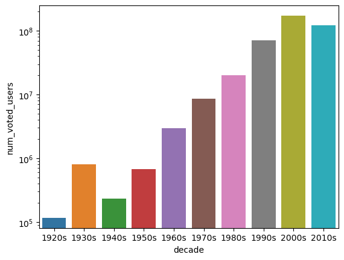

```python
#Plotting the bar graph
sns.barplot(x='decade',y='num_voted_users',data=df_by_decade)
plt.yscale('log')
plt.ylabel("num_voted_users")
plt.xlabel("decade")
plt.show()
```